# ggpage features

Emil Hvitfeldt

2019-06-13

## Variable paragraph length

```r
library(magrittr)
library(dplyr)
library(ggpage)


book <- tinderbox %>%
  tidytext::unnest_tokens(text, text)
```

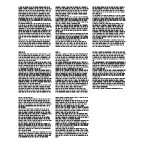

```r
ggpage_build(book, para.fun = rpois, lambda = 75) %>%
  ggpage_plot()
```

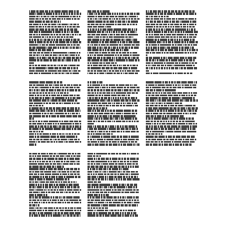

```r
ggpage_build(book, para.fun = rpois, lambda = 75) %>%
  ggpage_plot()
```

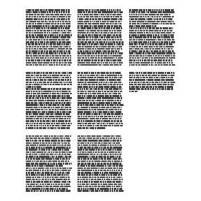

```r
ggpage_build(book, para.fun = rpois, lambda = 500) %>%
  ggpage_plot()
```

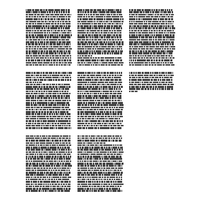

```r
ggpage_build(book, para.fun = rpois, lambda = 500) %>%
  ggpage_plot()
```

## Show paper

With the newest update `ggpage` allows you to draw a rectangle around each “page”.

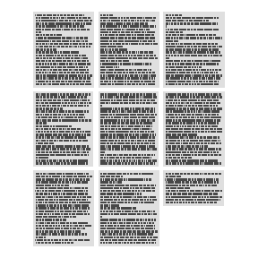

```r
ggpage_build(tinderbox) %>%
  ggpage_plot(paper.show = TRUE)
```

It allows you use specify a color both as a constant,

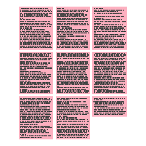

```r
ggpage_build(tinderbox) %>%
  ggpage_plot(paper.show = TRUE, paper.color = "pink")
```

or by a string of colors. In this case a faded rainbow.

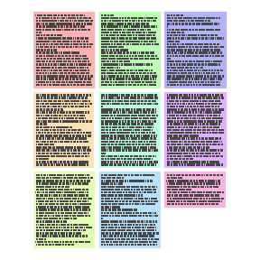

```r
ggpage_build(tinderbox) %>%
  ggpage_plot(paper.show = TRUE, paper.color = rainbow(9), paper.alpha = 0.3)
```

## Show page number

It can be hard to see the order of the pages in the standard vizualization. However it is possible to add a page number in the sides or corners of each page.

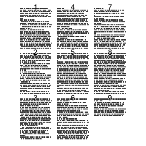

```r
directions <- c("top", "top-right", "right", "bottom-right", "bottom",
                "bottom-left", "left", "top-left")
ggpage_build(tinderbox) %>%
  ggpage_plot(page.number = directions[1])
```

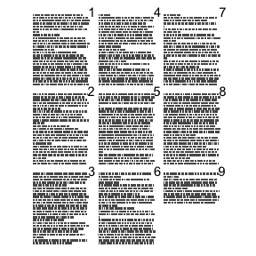

```r
ggpage_build(tinderbox) %>%
  ggpage_plot(page.number = directions[2])
```

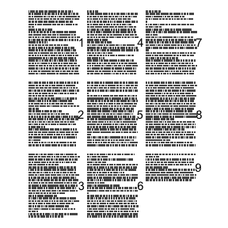

```r
ggpage_build(tinderbox) %>%
  ggpage_plot(page.number = directions[3])
```

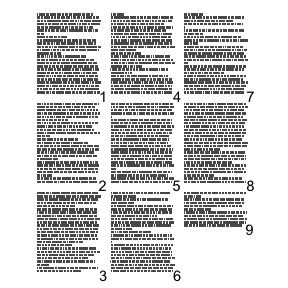

```r
ggpage_build(tinderbox) %>%
  ggpage_plot(page.number = directions[4])
```

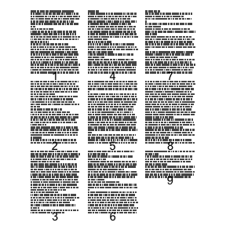

```r
ggpage_build(tinderbox) %>%
  ggpage_plot(page.number = directions[5])
```

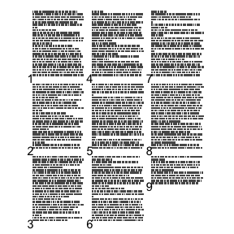

```r
ggpage_build(tinderbox) %>%
  ggpage_plot(page.number = directions[6])
```

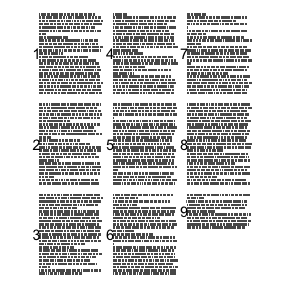

```r
ggpage_build(tinderbox) %>%
  ggpage_plot(page.number = directions[7])
```

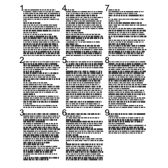

```r
ggpage_build(tinderbox) %>%
  ggpage_plot(page.number = directions[8])
```

## Variable page length

The package also support a variable page length. This can be helpful when a collection of smaller texts are considered in the same vizualisation such as tweets.

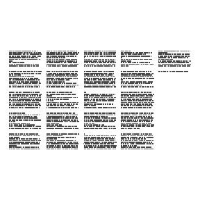

```r
tinderbox %>%
  mutate(short = ceiling(seq_len(nrow(tinderbox)) / 10)) %>%
  ggpage_build(page.col = "short", lpp = 10) %>%
  ggpage_plot()
```

## Centering

`ggpage` now supports left, right and both-sided alignments.

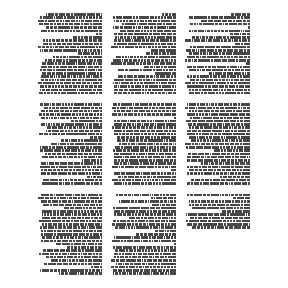

```r
ggpage_build(tinderbox, align = "right") %>%
  ggpage_plot()
```

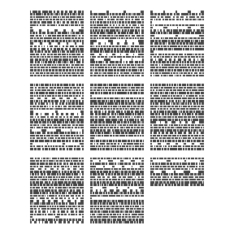

```r
ggpage_build(tinderbox, align = "both") %>%
  ggpage_plot()
```

## Paragraph to line

Lastly for convience does `ggpage` include a way to transform a data.frame with paragraph tokens to a data.frame with line tokens.

```r
nest_paragraphs(data = tinderbox_paragraph, input = text) %>%
  head()
```

```
#>                                                                               text
#> 1     A soldier came marching along the high road: "Left, right - left, right." He
#> 2  had his knapsack on his back, and a sword at his side; he had been to the wars,
#> 3 and was now returning home. As he walked on, he met a very frightful-looking old
#> 4  witch in the road. Her under-lip hung quite down on her breast, and she stopped
#> 5        and said, "Good evening, soldier; you have a very fine sword, and a large
#> 6    knapsack, and you are a real soldier; so you shall have as much money as ever
```

```r
nest_paragraphs(tinderbox_paragraph, text, width = 40) %>%
  head()
```

```
#>                                     text
#> 1 A soldier came marching along the high
#> 2  road: "Left, right - left, right." He
#> 3    had his knapsack on his back, and a
#> 4  sword at his side; he had been to the
#> 5   wars, and was now returning home. As
#> 6 he walked on, he met a very frightful-
```